# SQ 029

#### Solution

#### Question

13. An [ellipse](https://en.wikipedia.org/wiki/Ellipse) is the set of ($x$, $y$) points that satisfy the equation below.

    $$\frac{(x-h)^2}{(r_1)^2}+\frac{(y-k)^2}{(r_2)^2}=1$$

    where the center is $(h,k)$, the horizontal radius is $r_1$, and the vertical radius is $r_2$.

    Determine the parameters of the ellipse in the graph below. You can assume all parameters are integers.

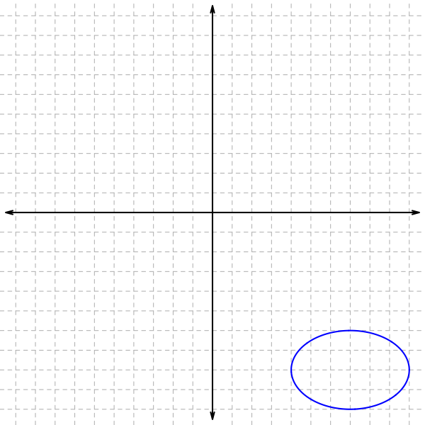

    - $h=$
    - $k=$
    - $r_1=$
    - $r_2=$

    Which of the following equations would give the graph above?

    $$\begin{align}
    A&:~~\frac{(x+7)^2}{4}+\frac{(y+8)^2}{9}=1 & B&:~~\frac{(x+7)^2}{4}+\frac{(y-8)^2}{9}=1 & C&:~~\frac{(x-7)^2}{4}+\frac{(y+8)^2}{9}=1 & D&:~~\frac{(x-7)^2}{4}+\frac{(y-8)^2}{9}=1 \\
    E&:~~\frac{(x+8)^2}{4}+\frac{(y+7)^2}{9}=1 & F&:~~\frac{(x+8)^2}{4}+\frac{(y-7)^2}{9}=1 & G&:~~\frac{(x-8)^2}{4}+\frac{(y+7)^2}{9}=1 & H&:~~\frac{(x-8)^2}{4}+\frac{(y-7)^2}{9}=1 \\
    I&:~~\frac{(x+7)^2}{9}+\frac{(y+8)^2}{4}=1 & J&:~~\frac{(x+7)^2}{9}+\frac{(y-8)^2}{4}=1 & K&:~~\frac{(x-7)^2}{9}+\frac{(y+8)^2}{4}=1 & L&:~~\frac{(x-7)^2}{9}+\frac{(y-8)^2}{4}=1 \\
    M&:~~\frac{(x+8)^2}{9}+\frac{(y+7)^2}{4}=1 & N&:~~\frac{(x+8)^2}{9}+\frac{(y-7)^2}{4}=1 & O&:~~\frac{(x-8)^2}{9}+\frac{(y+7)^2}{4}=1 & P&:~~\frac{(x-8)^2}{9}+\frac{(y-7)^2}{4}=1 \\
    \end{align}$$

    Equation

#### Solution

#### Question

14. An [ellipse](https://en.wikipedia.org/wiki/Ellipse) is the set of ($x$, $y$) points that satisfy the equation below.

    $$\frac{(x-h)^2}{(r_1)^2}+\frac{(y-k)^2}{(r_2)^2}=1$$

    where the center is $(h,k)$, the horizontal radius is $r_1$, and the vertical radius is $r_2$.

    Determine the parameters of the ellipse in the graph below. You can assume all parameters are integers.

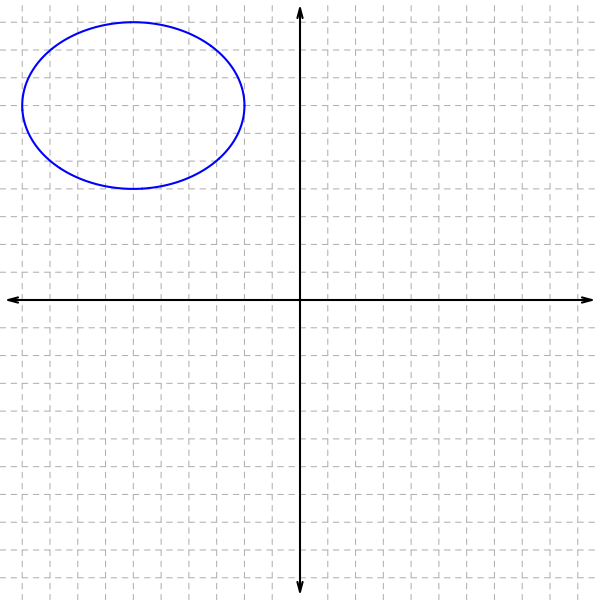

    - $h=$
    - $k=$
    - $r_1=$
    - $r_2=$

    Which of the following equations would give the graph above?

    $$\begin{align}
    A&:~~\frac{(x+6)^2}{9}+\frac{(y+7)^2}{16}=1 & B&:~~\frac{(x+6)^2}{9}+\frac{(y-7)^2}{16}=1 & C&:~~\frac{(x-6)^2}{9}+\frac{(y+7)^2}{16}=1 & D&:~~\frac{(x-6)^2}{9}+\frac{(y-7)^2}{16}=1 \\
    E&:~~\frac{(x+7)^2}{9}+\frac{(y+6)^2}{16}=1 & F&:~~\frac{(x+7)^2}{9}+\frac{(y-6)^2}{16}=1 & G&:~~\frac{(x-7)^2}{9}+\frac{(y+6)^2}{16}=1 & H&:~~\frac{(x-7)^2}{9}+\frac{(y-6)^2}{16}=1 \\
    I&:~~\frac{(x+6)^2}{16}+\frac{(y+7)^2}{9}=1 & J&:~~\frac{(x+6)^2}{16}+\frac{(y-7)^2}{9}=1 & K&:~~\frac{(x-6)^2}{16}+\frac{(y+7)^2}{9}=1 & L&:~~\frac{(x-6)^2}{16}+\frac{(y-7)^2}{9}=1 \\
    M&:~~\frac{(x+7)^2}{16}+\frac{(y+6)^2}{9}=1 & N&:~~\frac{(x+7)^2}{16}+\frac{(y-6)^2}{9}=1 & O&:~~\frac{(x-7)^2}{16}+\frac{(y+6)^2}{9}=1 & P&:~~\frac{(x-7)^2}{16}+\frac{(y-6)^2}{9}=1 \\
    \end{align}$$

    Equation

#### Solution

#### Question

15. An [ellipse](https://en.wikipedia.org/wiki/Ellipse) is the set of ($x$, $y$) points that satisfy the equation below.

    $$\frac{(x-h)^2}{(r_1)^2}+\frac{(y-k)^2}{(r_2)^2}=1$$

    where the center is $(h,k)$, the horizontal radius is $r_1$, and the vertical radius is $r_2$.

    Determine the parameters of the ellipse in the graph below. You can assume all parameters are integers.

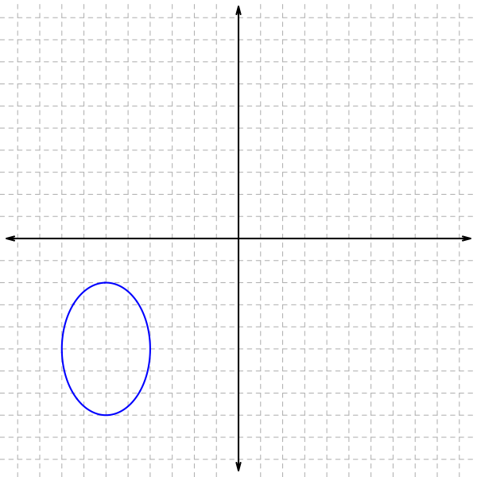

    - $h=$
    - $k=$
    - $r_1=$
    - $r_2=$

    Which of the following equations would give the graph above?

    $$\begin{align}
    A&:~~\frac{(x+5)^2}{4}+\frac{(y+6)^2}{9}=1 & B&:~~\frac{(x+5)^2}{4}+\frac{(y-6)^2}{9}=1 & C&:~~\frac{(x-5)^2}{4}+\frac{(y+6)^2}{9}=1 & D&:~~\frac{(x-5)^2}{4}+\frac{(y-6)^2}{9}=1 \\
    E&:~~\frac{(x+6)^2}{4}+\frac{(y+5)^2}{9}=1 & F&:~~\frac{(x+6)^2}{4}+\frac{(y-5)^2}{9}=1 & G&:~~\frac{(x-6)^2}{4}+\frac{(y+5)^2}{9}=1 & H&:~~\frac{(x-6)^2}{4}+\frac{(y-5)^2}{9}=1 \\
    I&:~~\frac{(x+5)^2}{9}+\frac{(y+6)^2}{4}=1 & J&:~~\frac{(x+5)^2}{9}+\frac{(y-6)^2}{4}=1 & K&:~~\frac{(x-5)^2}{9}+\frac{(y+6)^2}{4}=1 & L&:~~\frac{(x-5)^2}{9}+\frac{(y-6)^2}{4}=1 \\
    M&:~~\frac{(x+6)^2}{9}+\frac{(y+5)^2}{4}=1 & N&:~~\frac{(x+6)^2}{9}+\frac{(y-5)^2}{4}=1 & O&:~~\frac{(x-6)^2}{9}+\frac{(y+5)^2}{4}=1 & P&:~~\frac{(x-6)^2}{9}+\frac{(y-5)^2}{4}=1 \\
    \end{align}$$

    Equation

#### Solution

#### Question

16. An [ellipse](https://en.wikipedia.org/wiki/Ellipse) is the set of ($x$, $y$) points that satisfy the equation below.

    $$\frac{(x-h)^2}{(r_1)^2}+\frac{(y-k)^2}{(r_2)^2}=1$$

    where the center is $(h,k)$, the horizontal radius is $r_1$, and the vertical radius is $r_2$.

    Determine the parameters of the ellipse in the graph below. You can assume all parameters are integers.

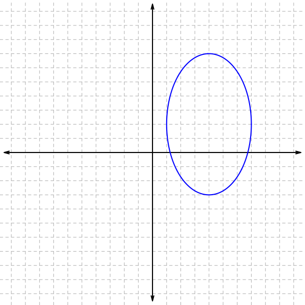

    - $h=$
    - $k=$
    - $r_1=$
    - $r_2=$

    Which of the following equations would give the graph above?

    $$\begin{align}
    A&:~~\frac{(x+2)^2}{9}+\frac{(y+4)^2}{25}=1 & B&:~~\frac{(x+2)^2}{9}+\frac{(y-4)^2}{25}=1 & C&:~~\frac{(x-2)^2}{9}+\frac{(y+4)^2}{25}=1 & D&:~~\frac{(x-2)^2}{9}+\frac{(y-4)^2}{25}=1 \\
    E&:~~\frac{(x+4)^2}{9}+\frac{(y+2)^2}{25}=1 & F&:~~\frac{(x+4)^2}{9}+\frac{(y-2)^2}{25}=1 & G&:~~\frac{(x-4)^2}{9}+\frac{(y+2)^2}{25}=1 & H&:~~\frac{(x-4)^2}{9}+\frac{(y-2)^2}{25}=1 \\
    I&:~~\frac{(x+2)^2}{25}+\frac{(y+4)^2}{9}=1 & J&:~~\frac{(x+2)^2}{25}+\frac{(y-4)^2}{9}=1 & K&:~~\frac{(x-2)^2}{25}+\frac{(y+4)^2}{9}=1 & L&:~~\frac{(x-2)^2}{25}+\frac{(y-4)^2}{9}=1 \\
    M&:~~\frac{(x+4)^2}{25}+\frac{(y+2)^2}{9}=1 & N&:~~\frac{(x+4)^2}{25}+\frac{(y-2)^2}{9}=1 & O&:~~\frac{(x-4)^2}{25}+\frac{(y+2)^2}{9}=1 & P&:~~\frac{(x-4)^2}{25}+\frac{(y-2)^2}{9}=1 \\
    \end{align}$$

    Equation

#### Solution

#### Question

17. An [ellipse](https://en.wikipedia.org/wiki/Ellipse) is the set of ($x$, $y$) points that satisfy the equation below.

    $$\frac{(x-h)^2}{(r_1)^2}+\frac{(y-k)^2}{(r_2)^2}=1$$

    where the center is $(h,k)$, the horizontal radius is $r_1$, and the vertical radius is $r_2$.

    Determine the parameters of the ellipse in the graph below. You can assume all parameters are integers.

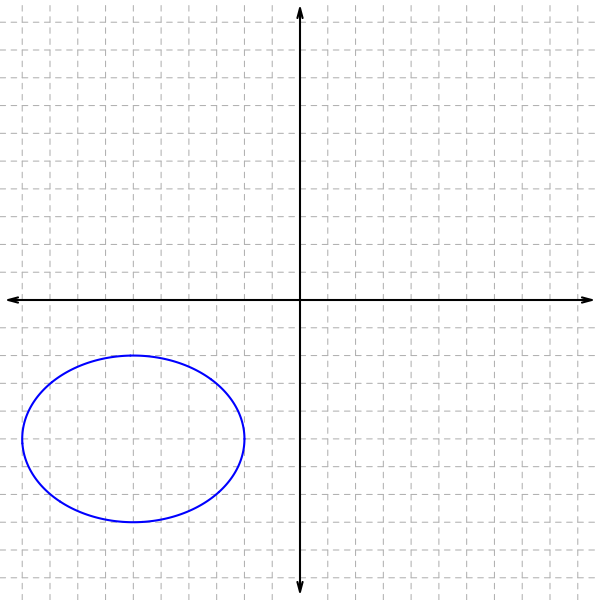

    - $h=$
    - $k=$
    - $r_1=$
    - $r_2=$

    Which of the following equations would give the graph above?

    $$\begin{align}
    A&:~~\frac{(x+5)^2}{9}+\frac{(y+6)^2}{16}=1 & B&:~~\frac{(x+5)^2}{9}+\frac{(y-6)^2}{16}=1 & C&:~~\frac{(x-5)^2}{9}+\frac{(y+6)^2}{16}=1 & D&:~~\frac{(x-5)^2}{9}+\frac{(y-6)^2}{16}=1 \\
    E&:~~\frac{(x+6)^2}{9}+\frac{(y+5)^2}{16}=1 & F&:~~\frac{(x+6)^2}{9}+\frac{(y-5)^2}{16}=1 & G&:~~\frac{(x-6)^2}{9}+\frac{(y+5)^2}{16}=1 & H&:~~\frac{(x-6)^2}{9}+\frac{(y-5)^2}{16}=1 \\
    I&:~~\frac{(x+5)^2}{16}+\frac{(y+6)^2}{9}=1 & J&:~~\frac{(x+5)^2}{16}+\frac{(y-6)^2}{9}=1 & K&:~~\frac{(x-5)^2}{16}+\frac{(y+6)^2}{9}=1 & L&:~~\frac{(x-5)^2}{16}+\frac{(y-6)^2}{9}=1 \\
    M&:~~\frac{(x+6)^2}{16}+\frac{(y+5)^2}{9}=1 & N&:~~\frac{(x+6)^2}{16}+\frac{(y-5)^2}{9}=1 & O&:~~\frac{(x-6)^2}{16}+\frac{(y+5)^2}{9}=1 & P&:~~\frac{(x-6)^2}{16}+\frac{(y-5)^2}{9}=1 \\
    \end{align}$$

    Equation

#### Solution

#### Question

18. An [ellipse](https://en.wikipedia.org/wiki/Ellipse) is the set of ($x$, $y$) points that satisfy the equation below.

    $$\frac{(x-h)^2}{(r_1)^2}+\frac{(y-k)^2}{(r_2)^2}=1$$

    where the center is $(h,k)$, the horizontal radius is $r_1$, and the vertical radius is $r_2$.

    Determine the parameters of the ellipse in the graph below. You can assume all parameters are integers.

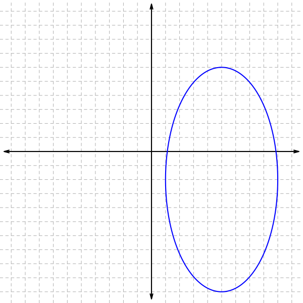

    - $h=$
    - $k=$
    - $r_1=$
    - $r_2=$

    Which of the following equations would give the graph above?

    $$\begin{align}
    A&:~~\frac{(x+2)^2}{16}+\frac{(y+5)^2}{64}=1 & B&:~~\frac{(x+2)^2}{16}+\frac{(y-5)^2}{64}=1 & C&:~~\frac{(x-2)^2}{16}+\frac{(y+5)^2}{64}=1 & D&:~~\frac{(x-2)^2}{16}+\frac{(y-5)^2}{64}=1 \\
    E&:~~\frac{(x+5)^2}{16}+\frac{(y+2)^2}{64}=1 & F&:~~\frac{(x+5)^2}{16}+\frac{(y-2)^2}{64}=1 & G&:~~\frac{(x-5)^2}{16}+\frac{(y+2)^2}{64}=1 & H&:~~\frac{(x-5)^2}{16}+\frac{(y-2)^2}{64}=1 \\
    I&:~~\frac{(x+2)^2}{64}+\frac{(y+5)^2}{16}=1 & J&:~~\frac{(x+2)^2}{64}+\frac{(y-5)^2}{16}=1 & K&:~~\frac{(x-2)^2}{64}+\frac{(y+5)^2}{16}=1 & L&:~~\frac{(x-2)^2}{64}+\frac{(y-5)^2}{16}=1 \\
    M&:~~\frac{(x+5)^2}{64}+\frac{(y+2)^2}{16}=1 & N&:~~\frac{(x+5)^2}{64}+\frac{(y-2)^2}{16}=1 & O&:~~\frac{(x-5)^2}{64}+\frac{(y+2)^2}{16}=1 & P&:~~\frac{(x-5)^2}{64}+\frac{(y-2)^2}{16}=1 \\
    \end{align}$$

    Equation

#### Solution

#### Question

19. An [ellipse](https://en.wikipedia.org/wiki/Ellipse) is the set of ($x$, $y$) points that satisfy the equation below.

    $$\frac{(x-h)^2}{(r_1)^2}+\frac{(y-k)^2}{(r_2)^2}=1$$

    where the center is $(h,k)$, the horizontal radius is $r_1$, and the vertical radius is $r_2$.

    Determine the parameters of the ellipse in the graph below. You can assume all parameters are integers.

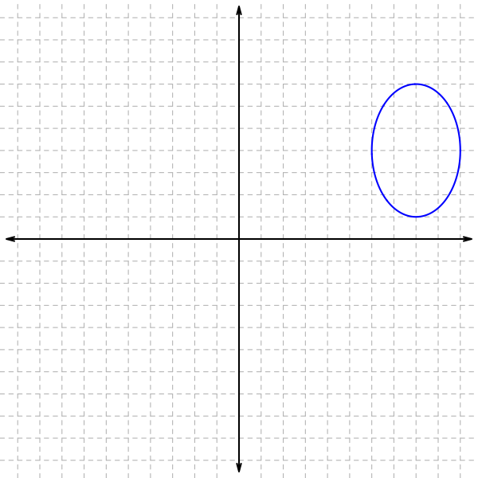

    - $h=$
    - $k=$
    - $r_1=$
    - $r_2=$

    Which of the following equations would give the graph above?

    $$\begin{align}
    A&:~~\frac{(x+4)^2}{4}+\frac{(y+8)^2}{9}=1 & B&:~~\frac{(x+4)^2}{4}+\frac{(y-8)^2}{9}=1 & C&:~~\frac{(x-4)^2}{4}+\frac{(y+8)^2}{9}=1 & D&:~~\frac{(x-4)^2}{4}+\frac{(y-8)^2}{9}=1 \\
    E&:~~\frac{(x+8)^2}{4}+\frac{(y+4)^2}{9}=1 & F&:~~\frac{(x+8)^2}{4}+\frac{(y-4)^2}{9}=1 & G&:~~\frac{(x-8)^2}{4}+\frac{(y+4)^2}{9}=1 & H&:~~\frac{(x-8)^2}{4}+\frac{(y-4)^2}{9}=1 \\
    I&:~~\frac{(x+4)^2}{9}+\frac{(y+8)^2}{4}=1 & J&:~~\frac{(x+4)^2}{9}+\frac{(y-8)^2}{4}=1 & K&:~~\frac{(x-4)^2}{9}+\frac{(y+8)^2}{4}=1 & L&:~~\frac{(x-4)^2}{9}+\frac{(y-8)^2}{4}=1 \\
    M&:~~\frac{(x+8)^2}{9}+\frac{(y+4)^2}{4}=1 & N&:~~\frac{(x+8)^2}{9}+\frac{(y-4)^2}{4}=1 & O&:~~\frac{(x-8)^2}{9}+\frac{(y+4)^2}{4}=1 & P&:~~\frac{(x-8)^2}{9}+\frac{(y-4)^2}{4}=1 \\
    \end{align}$$

    Equation

#### Solution

#### Question

20. An [ellipse](https://en.wikipedia.org/wiki/Ellipse) is the set of ($x$, $y$) points that satisfy the equation below.

    $$\frac{(x-h)^2}{(r_1)^2}+\frac{(y-k)^2}{(r_2)^2}=1$$

    where the center is $(h,k)$, the horizontal radius is $r_1$, and the vertical radius is $r_2$.

    Determine the parameters of the ellipse in the graph below. You can assume all parameters are integers.

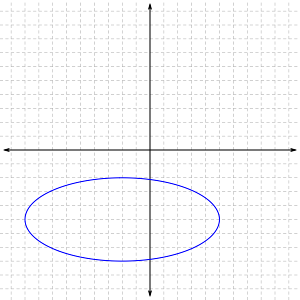

    - $h=$
    - $k=$
    - $r_1=$
    - $r_2=$

    Which of the following equations would give the graph above?

    $$\begin{align}
    A&:~~\frac{(x+2)^2}{9}+\frac{(y+5)^2}{49}=1 & B&:~~\frac{(x+2)^2}{9}+\frac{(y-5)^2}{49}=1 & C&:~~\frac{(x-2)^2}{9}+\frac{(y+5)^2}{49}=1 & D&:~~\frac{(x-2)^2}{9}+\frac{(y-5)^2}{49}=1 \\
    E&:~~\frac{(x+5)^2}{9}+\frac{(y+2)^2}{49}=1 & F&:~~\frac{(x+5)^2}{9}+\frac{(y-2)^2}{49}=1 & G&:~~\frac{(x-5)^2}{9}+\frac{(y+2)^2}{49}=1 & H&:~~\frac{(x-5)^2}{9}+\frac{(y-2)^2}{49}=1 \\
    I&:~~\frac{(x+2)^2}{49}+\frac{(y+5)^2}{9}=1 & J&:~~\frac{(x+2)^2}{49}+\frac{(y-5)^2}{9}=1 & K&:~~\frac{(x-2)^2}{49}+\frac{(y+5)^2}{9}=1 & L&:~~\frac{(x-2)^2}{49}+\frac{(y-5)^2}{9}=1 \\
    M&:~~\frac{(x+5)^2}{49}+\frac{(y+2)^2}{9}=1 & N&:~~\frac{(x+5)^2}{49}+\frac{(y-2)^2}{9}=1 & O&:~~\frac{(x-5)^2}{49}+\frac{(y+2)^2}{9}=1 & P&:~~\frac{(x-5)^2}{49}+\frac{(y-2)^2}{9}=1 \\
    \end{align}$$

    Equation

#### Solution